# Regression - Deep EDA

Claire Liu

### 本週主題：納入統計學

- 敘述統計：沒有假設機率模型，關注的是如何 summarize 資料也就是用幾個簡單的數字 把資料的大致趨勢或分配作出統整。
- 假設檢定： [[學習筆記]統計學：假設檢定 (Hypothesis Testing)](http://murphymind.blogspot.com/2011/12/hypothesis-testing.html)
1. T-test：用來比較兩個群體的平均數（ 只能一次比較兩組 ）
2. ANOVA：適合連續型因子推測非連續型因子
- 迴歸分析：透過 W 值做未來的預測，但未來有可能會改變，所以回歸不是用股票預測，因為不穩定，穩定的狀況例如生物狀態（ 長高、長胖 ），在分佈是一致的時候方可使用
- 機器學習：當有一個數學封閉解的時候，表示有精確解；但很多時候，我們找不到或是還找到，就必須透過有限範圍的 training，在機器學習中找到近似的答案。

> Regression 是透過一些統計的技巧，幫助了解資料欄位之間的關聯性。

### Data Set : 來自TIMSS 的統計資料

該資料集內包含了韓國、日本、台灣、香港四個國家，共計 15000 多位學生在數理方面的成績與讀書環境，包含是否有電腦、書桌、網路、自己的房間、書與書量，以及家長教育程度。

### Geting & Viewing data

```r
# read data
data <- read.table(file = "data/TIMSSmath.txt", header = TRUE)
# show data
head(data)
```

```
##   國家 性別 父母教育     數學     化學     地科     生物     物理 電腦
## 1 台灣 女生     高中 729.3937 624.7918 607.8187 650.6866 618.3397   有
## 2 台灣 女生     高中 776.1965 661.7790 665.7075 627.9452 616.7004   有
## 3 台灣 女生 國小以下 718.1735 708.7784 629.3393 617.4507 663.3176   有
## 4 台灣 女生     初中 607.1847 632.9836 620.3192 592.0527 616.4611   有
## 5 台灣 女生 大學以上 658.1759 617.8183 614.0907 560.1919 591.0047   有
## 6 台灣 女生     專科 478.5763 601.2205 591.0417 598.7882 553.9959   有
##   書桌 書 房間 網路      書量
## 1   無 有   無   有  26-100本
## 2   有 有   無   有   11-25本
## 3   有 無   無   有  10本以下
## 4   無 無   無   有 200本以上
## 5   無 無   無   有  26-100本
## 6   有 有   有   有  26-100本
```

```r
# preview structure of data
str(data)
```

```
## 'data.frame':    15549 obs. of  14 variables:
##  $ 國家    : Factor w/ 4 levels "韓國","日本",..: 3 3 3 3 3 3 3 3 3 3 ...
##  $ 性別    : Factor w/ 2 levels "男生","女生": 2 2 2 2 2 2 2 2 2 2 ...
##  $ 父母教育: Factor w/ 5 levels "初中","大學以上",..: 3 3 4 1 2 5 3 2 1 3 ...
##  $ 數學    : num  729 776 718 607 658 ...
##  $ 化學    : num  625 662 709 633 618 ...
##  $ 地科    : num  608 666 629 620 614 ...
##  $ 生物    : num  651 628 617 592 560 ...
##  $ 物理    : num  618 617 663 616 591 ...
##  $ 電腦    : Factor w/ 2 levels "無","有": 2 2 2 2 2 2 2 2 2 2 ...
##  $ 書桌    : Factor w/ 2 levels "無","有": 1 2 2 1 1 2 2 2 2 2 ...
##  $ 書      : Factor w/ 2 levels "無","有": 2 2 1 1 1 2 2 2 2 2 ...
##  $ 房間    : Factor w/ 2 levels "無","有": 1 1 1 1 1 2 1 2 2 2 ...
##  $ 網路    : Factor w/ 2 levels "無","有": 2 2 2 2 2 2 2 2 2 2 ...
##  $ 書量    : Factor w/ 5 levels "101-200本","10本以下",..: 5 3 2 4 5 5 3 5 5 1 ...
```

```r
# preview summary of data
summary(data)
```

```
##    國家        性別          父母教育         數學            化學
##  韓國:4345   男生:7496   初中    :1291   Min.   :136.2   Min.   :227.5
##  日本:3420   女生:8053   大學以上:5502   1st Qu.:546.0   1st Qu.:509.5
##  台灣:4535               高中    :6375   Median :609.3   Median :565.6
##  香港:3249               國小以下: 384   Mean   :603.2   Mean   :564.4
##                          專科    :1997   3rd Qu.:666.3   3rd Qu.:621.4
##                                          Max.   :918.1   Max.   :909.7
##       地科            生物            物理       電腦       書桌
##  Min.   :172.2   Min.   :196.0   Min.   :151.9   無:  496   無: 1589
##  1st Qu.:507.5   1st Qu.:510.4   1st Qu.:510.8   有:15053   有:13960
##  Median :563.1   Median :565.6   Median :568.0
##  Mean   :558.8   Mean   :560.3   Mean   :563.9
##  3rd Qu.:613.9   3rd Qu.:614.2   3rd Qu.:621.2
##  Max.   :848.2   Max.   :829.1   Max.   :852.5
##   書        房間       網路              書量
##  無: 1265   無: 4771   無:  930   101-200本:2761
##  有:14284   有:10778   有:14619   10本以下 :2054
##                                   11-25本  :2875
##                                   200本以上:3367
##                                   26-100本 :4492
##
```

### EDA of data

> 下面用幾個簡單的圖表詮釋並暸解資料

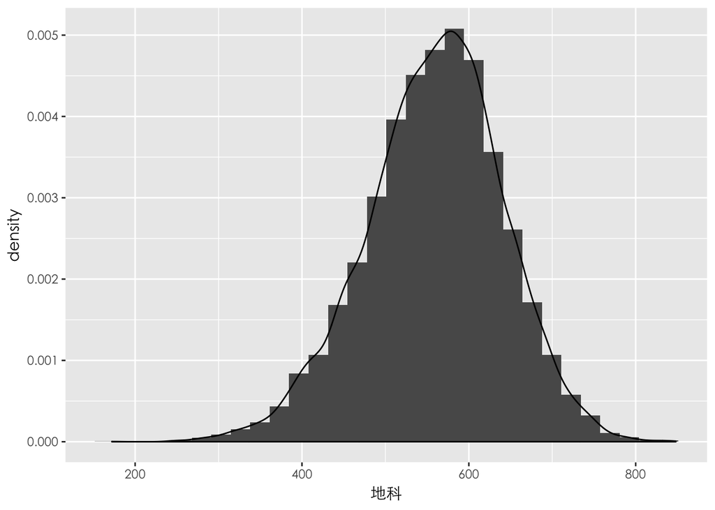

```r
library(ggplot2)
ggplot(data) +
  geom_histogram(aes(x=地科,y=..density..), position="identity") +
  geom_density(aes(x=地科,y=..density..)) +
  theme(text=element_text(family="Heiti TC Light"))
```

### 問題定義：連續變數 vs. 連續變數

> 分數之間是否存在某種關係，例如數學不好，物理就不好等等的。

##### 比較兩兩分數間的關係，了解所有學科分數之間的相關性

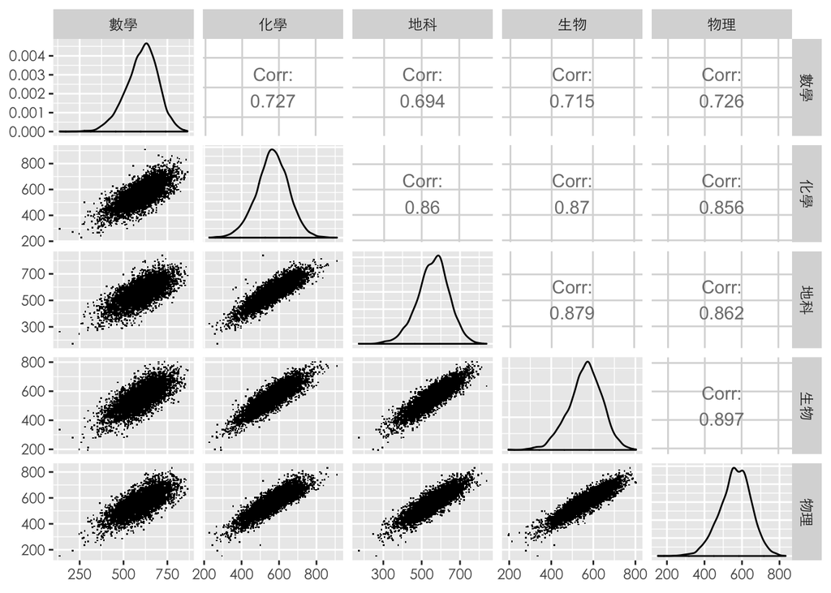

```r
library(GGally)
set.seed(10000)
data.samp <- subset(data, select = c(4:8))
data.samp <- data.samp[sample(1:length(data$國家), 5000), ]
ggpairs(data.samp,
        lower = list(continuous = wrap("points", shape = I('.'))),
        upper = list(combo = wrap("box", outlier.shape = I('.')))) +
  theme(text=element_text(family="Heiti TC Light"))
```

##### 檢定數學與物理相關性是否顯著，也可以看到信賴區間

> cor.test : 相關性檢測，可檢定 t 值、df ( 自由度 )、p值、顯著與信賴區間。

檢測結果說明兩者有相關。所以我們可以知道數學不好，物理成績也不會好。

```r
cor.test( ~ 數學 + 物理, data = data[,4:8])
```

```
##
##  Pearson's product-moment correlation
##
## data:  數學 and 物理
## t = 131.06, df = 15547, p-value < 2.2e-16
## alternative hypothesis: true correlation is not equal to 0
## 95 percent confidence interval:
##  0.7169507 0.7318879
## sample estimates:
##       cor
## 0.7245044
```

```r
cor.test( ~ 數學 + 生物, data = data[,4:8])
```

```
##
##  Pearson's product-moment correlation
##
## data:  數學 and 生物
## t = 126.01, df = 15547, p-value < 2.2e-16
## alternative hypothesis: true correlation is not equal to 0
## 95 percent confidence interval:
##  0.7029750 0.7185288
## sample estimates:
##       cor
## 0.7108388
```

無法直接比較 p 值，但可以參考 cor 檢測的值

```r
#載進 Hmist，一次檢定所有相關
require(Hmisc)
rcorr(as.matrix(data[,4:8]), type=c("pearson","spearman"))
```

```
##      數學 化學 地科 生物 物理
## 數學 1.00 0.72 0.69 0.71 0.72
## 化學 0.72 1.00 0.86 0.87 0.86
## 地科 0.69 0.86 1.00 0.88 0.86
## 生物 0.71 0.87 0.88 1.00 0.90
## 物理 0.72 0.86 0.86 0.90 1.00
##
## n= 15549
##
##
## P
##      數學 化學 地科 生物 物理
## 數學       0    0    0    0
## 化學  0         0    0    0
## 地科  0    0         0    0
## 生物  0    0    0         0
## 物理  0    0    0    0
```

##### Null hypothesis rejected

```r
#檢驗數學與物理、數學與生物何者相關高
require(cocor)
cocor(~數學 + 物理 | 數學 + 生物, data[,4:8])
```

[output not shown]

### 問題定義：連續變數 vs. 類別變數

> 在資料中包含讀書環境或家長因素，想先找出哪些科目和性別有關係，然後再慢慢加進其他的變因，來完成模型的建立。

### Part A. 性別 vs 數學成績

> 數學成績和性別沒有顯著關係。

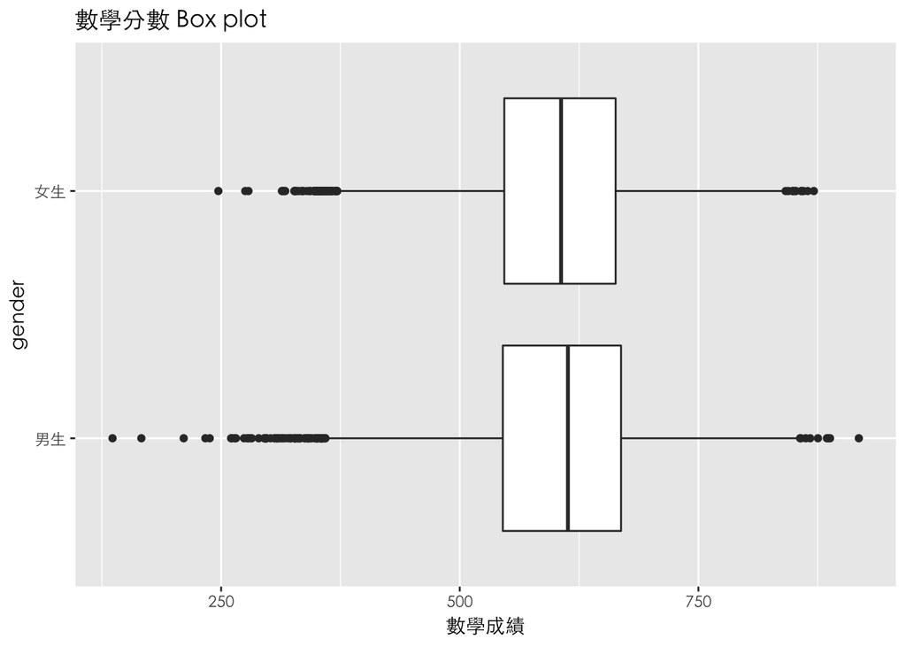

```r
ggplot(data = data, aes(x = 性別, y = 數學)) +
  geom_boxplot() + coord_flip() +
  labs( y = "數學成績", x = "gender", title = '數學分數 Box plot') +
  theme(text=element_text(family="Heiti TC Light"))
```

```r
#以下函式計算95%信賴區間
with(data,
     tapply(數學, 性別,
     function(x)
       c(mean(x) + c(-2, 2) * sd(x)/sqrt(length(x)))))
```

```
## $男生
## [1] 602.2772 606.6488
##
## $女生
## [1] 600.0391 603.9618
```

### 以 t-test 檢驗不同性別是否存在數學成績差異

### T test

> 這是通常用於某種資料，在觀察資料的時候，無法固定其中某些不確定因素，為了消除混雜因素的影響使其他因素不變，而採用的測試方法。

以下為例，很明顯得 T-test 的 p 值大於等於 0.05，所以可以推測數學成績和性別沒有直接的關係

```r
#此函數會預設進行 Welch 校正，以處理兩樣本變異數不相同的問題
t.test(數學 ~ 性別, data = data)
```

```
##
##  Welch Two Sample t-test
##
## data:  數學 by 性別
## t = 1.6771, df = 15232, p-value = 0.09355
## alternative hypothesis: true difference in means is not equal to 0
## 95 percent confidence interval:
##  -0.415622  5.340795
## sample estimates:
## mean in group 男生 mean in group 女生
##           604.4630           602.0004
```

```r
#可加上參數 var.equal=TRUE 來假設變異數同值(不做Welch校正)
t.test(數學 ~ 性別, data = data, var.equal = TRUE)
```

```
##
##  Two Sample t-test
##
## data:  數學 by 性別
## t = 1.6814, df = 15547, p-value = 0.0927
## alternative hypothesis: true difference in means is not equal to 0
## 95 percent confidence interval:
##  -0.4081631  5.3333365
## sample estimates:
## mean in group 男生 mean in group 女生
##           604.4630           602.0004
```

### Part B. 性別 vs 地科成績 vs. 國家

#### 以下觀察國家是否與地科成績有關

> 台灣在地科這方面的成績似乎比其他國家來得好

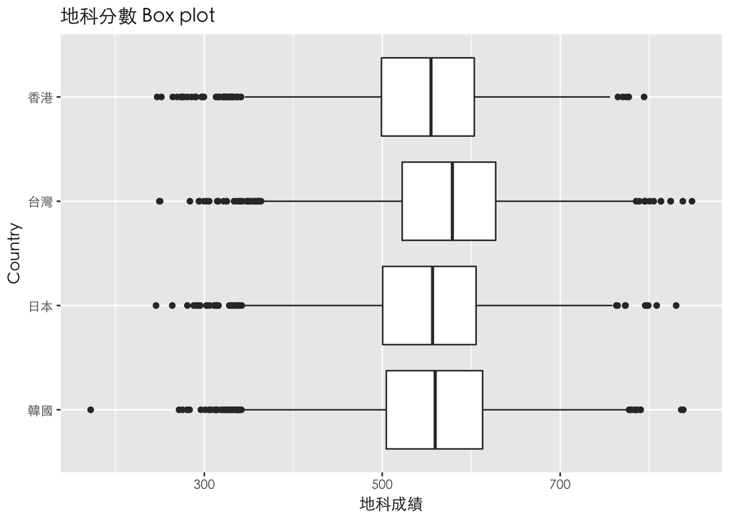

```r
ggplot(data = data, aes(x = 國家, y = 地科)) +
  geom_boxplot() + coord_flip() +
  labs( y = "地科成績", x =  "Country", title = '地科分數 Box plot') +
  theme(text=element_text(family="Heiti TC Light"))
```

```r
#以下函式計算95%信賴區間
with(data,
     tapply(地科, 國家,
     function(x)
       c(mean(x) + c(-2, 2) * sd(x)/sqrt(length(x)))))
```

```
## $韓國
## [1] 554.8464 559.9128
##
## $日本
## [1] 548.6535 554.1736
##
## $台灣
## [1] 571.2325 575.9896
##
## $香港
## [1] 545.1626 550.8312
```

#### 以下觀察性別是否與地科成績有關

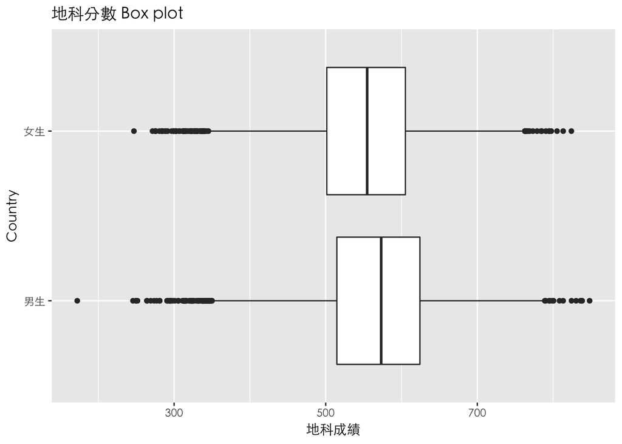

```r
ggplot(data = data, aes(x = 性別, y = 地科)) +
  geom_boxplot() + coord_flip() +
  labs( y = "地科成績", x =  "Country", title = '地科分數 Box plot') +
  theme(text=element_text(family="Heiti TC Light"))
```

```r
#以下函式計算95%信賴區間
with(data,
     tapply(地科, 性別,
     function(x)
       c(mean(x) + c(-2, 2) * sd(x)/sqrt(length(x)))))
```

```
## $男生
## [1] 564.6516 568.5660
##
## $女生
## [1] 549.8590 553.3615
```

### T testing ( T 檢測 )

我們找到了一個科目和性別有直接的關係。下面可以很清楚的看到 T-test 的 p 值小於等於 0.05，所以可以推測地科成績和性別有直接的關係。

```r
#此函數會預設進行 Welch 校正，以處理兩樣本變異數不相同的問題
t.test(地科 ~ 性別, data = data)
```

```
##
##  Welch Two Sample t-test
##
## data:  地科 by 性別
## t = 11.422, df = 15220, p-value < 2.2e-16
## alternative hypothesis: true difference in means is not equal to 0
## 95 percent confidence interval:
##  12.42461 17.57251
## sample estimates:
## mean in group 男生 mean in group 女生
##           566.6088           551.6102
```

```r
#可加上參數 var.equal=TRUE 來假設變異數同值(不做Welch校正)
t.test(地科 ~ 性別, data = data, var.equal = TRUE)
```

```
##
##  Two Sample t-test
##
## data:  地科 by 性別
## t = 11.453, df = 15547, p-value < 2.2e-16
## alternative hypothesis: true difference in means is not equal to 0
## 95 percent confidence interval:
##  12.43153 17.56558
## sample estimates:
## mean in group 男生 mean in group 女生
##           566.6088           551.6102
```

```r
library(Hmisc)
#看不同性別下的地科分數平均數
tapply(data$地科, data$性別, mean)
```

```
##     男生     女生
## 566.6088 551.6102
```

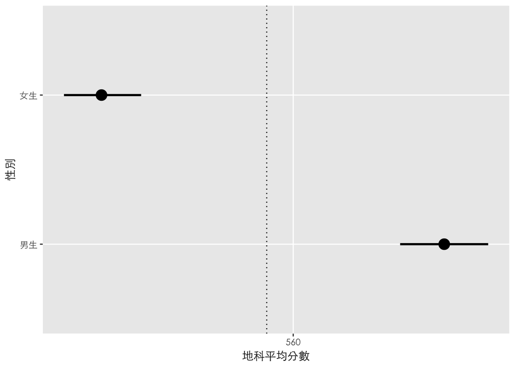

```r
# 相同國家的地科分數平均數，加上信賴區間
ggplot(data = data,
       aes(x = 性別, y = 地科)) +
  stat_summary(fun.data = 'mean_cl_boot', size = 1) +
  scale_y_continuous(breaks = seq(500, 660, by = 20)) +
  geom_hline(yintercept = mean(data$地科) ,
             linetype = 'dotted') +
  labs(x = '性別', y = '地科平均分數') +
  coord_flip() +
  theme(text=element_text(family="Heiti TC Light"))
```

#### 在這裡我們推測不同性別的地科成績，可能是因為不同書量造成的，畫圖觀察看看

### ANOVA 檢驗假設

```r
anova(m1 <- lm(地科 ~ 性別, data = data))
```

```
## Analysis of Variance Table
##
## Response: 地科
##              Df    Sum Sq Mean Sq F value    Pr(>F)
## 性別          1    873341  873341  131.16 < 2.2e-16 ***
## Residuals 15547 103520512    6659
## ---
## Signif. codes:  0 '***' 0.001 '**' 0.01 '*' 0.05 '.' 0.1 ' ' 1
```

```r
library(magrittr)
library(dplyr)
```

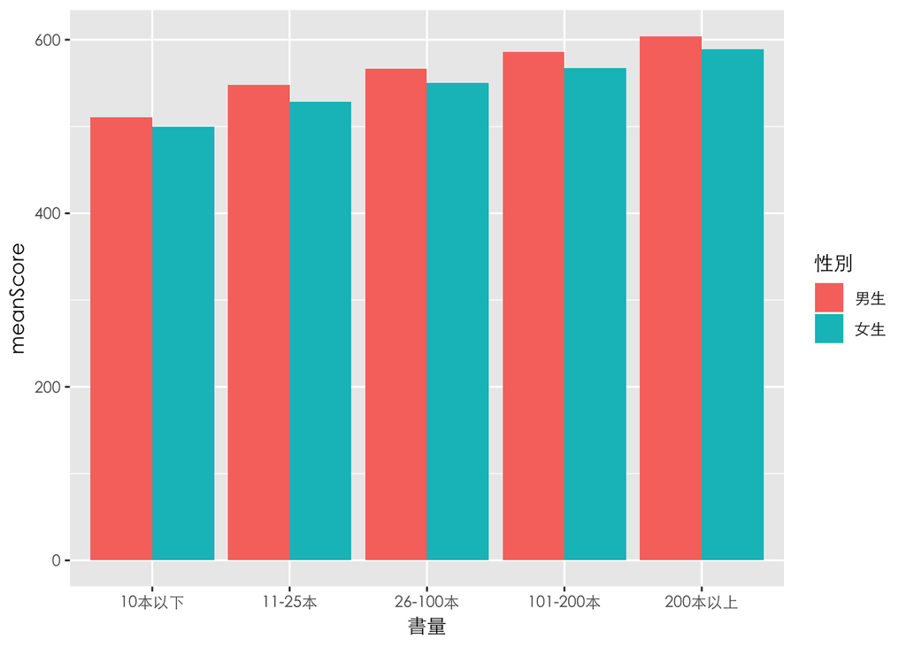

```r
data$書量 <- factor(data$書量, levels = c("10本以下", "11-25本",  "26-100本", "101-200本","200本以上"))

data %>%
  group_by(書量, 性別) %>%
  summarise(meanScore = mean(地科)) %>%
  ggplot(aes(x=書量, y=meanScore, fill=性別)) +
  geom_histogram(stat="identity", position="dodge") +
  theme(text=element_text(family="Heiti TC Light"))
```

### 利用以下 ANOVA 檢驗假設是否正確

```r
# 把書量加進模型
anova(m2 <- update(m1, . ~ . + 書量, data = data))
```

```
## Analysis of Variance Table
##
## Response: 地科
##              Df   Sum Sq Mean Sq F value    Pr(>F)
## 性別          1   873341  873341  149.67 < 2.2e-16 ***
## 書量          4 12827580 3206895  549.60 < 2.2e-16 ***
## Residuals 15543 90692932    5835
## ---
## Signif. codes:  0 '***' 0.001 '**' 0.01 '*' 0.05 '.' 0.1 ' ' 1
```

```r
# 或許不是性別而是國家造成
anova(m3 <- update(m2, . ~ . - 性別 + 國家,  data = data))
```

```
## Analysis of Variance Table
##
## Response: 地科
##              Df   Sum Sq Mean Sq F value    Pr(>F)
## 書量          4 12687385 3171846  550.34 < 2.2e-16 ***
## 國家          3  2137304  712435  123.61 < 2.2e-16 ***
## Residuals 15541 89569164    5763
## ---
## Signif. codes:  0 '***' 0.001 '**' 0.01 '*' 0.05 '.' 0.1 ' ' 1
```

### 將 ANOVA 結果做成圖表輸出，先計算一些需要的數據

```r
#將結果放在一個list中
res_lm <- lapply(list(m1, m2, m3), summary)
#比較在控制教育資源下，父母教育的效果
(res_lm[[2]]$r.sq - res_lm[[3]]$r.sq)/res_lm[[2]]$r.sq
```

```
## [1] -0.08202138
```

```r
anova(m3, m2)
```

```
## Analysis of Variance Table
##
## Model 1: 地科 ~ 書量 + 國家
## Model 2: 地科 ~ 性別 + 書量
##   Res.Df      RSS Df Sum of Sq      F    Pr(>F)
## 1  15541 89569164
## 2  15543 90692932 -2  -1123768 97.492 < 2.2e-16 ***
## ---
## Signif. codes:  0 '***' 0.001 '**' 0.01 '*' 0.05 '.' 0.1 ' ' 1
```

```r
#比較在控制父母教育下，教育資源的效果
(res_lm[[2]]$r.sq - res_lm[[1]]$r.sq)/res_lm[[1]]$r.sq
```

```
## [1] 14.68794
```

```r
anova(m1, m2)
```

```
## Analysis of Variance Table
##
## Model 1: 地科 ~ 性別
## Model 2: 地科 ~ 性別 + 書量
##   Res.Df       RSS Df Sum of Sq     F    Pr(>F)
## 1  15547 103520512
## 2  15543  90692932  4  12827580 549.6 < 2.2e-16 ***
## ---
## Signif. codes:  0 '***' 0.001 '**' 0.01 '*' 0.05 '.' 0.1 ' ' 1
```

### 正式畫圖

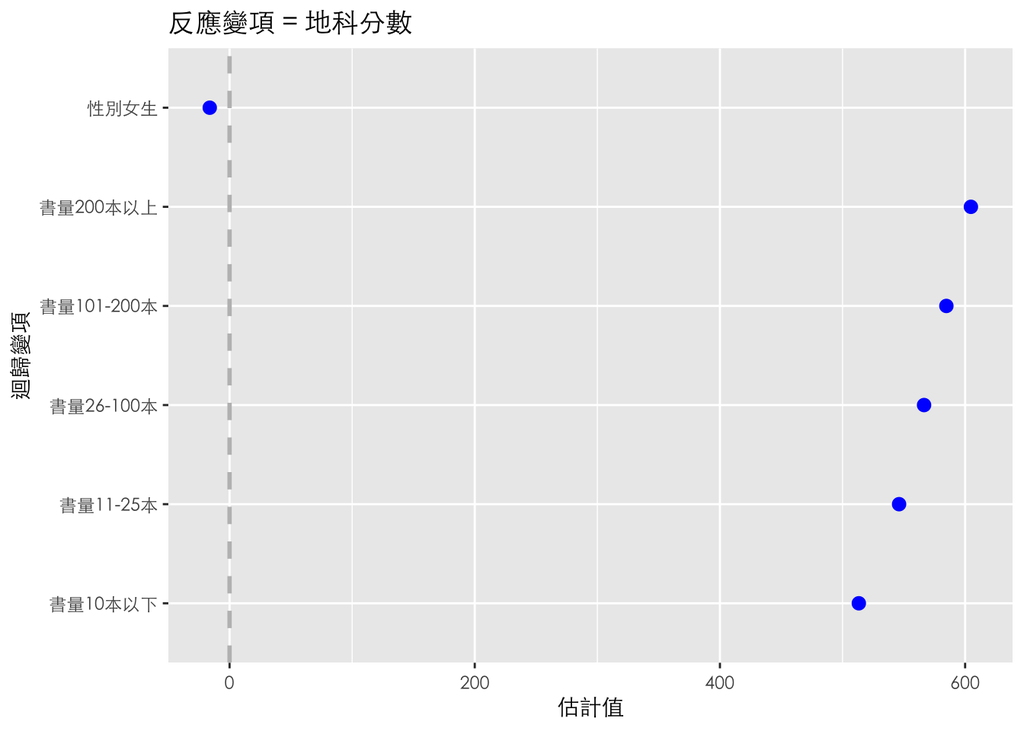

```r
require(coefplot)
m2 <- lm(地科 ~ 書量 + 性別 - 1,  data = data)
coefplot(m2, xlab = '估計值', ylab = '迴歸變項', title = '反應變項 = 地科分數') +
  theme(text=element_text(family="Heiti TC Light"))
```

### 加入資料與迴歸分析的預測值、殘差與影響度

```r
fit_m2 <- data.frame(data[, c(1, 6, 2, 9, 10, 11)],
                     fitted = fitted(m2),
                     resid = resid(m2),
                     infl = influence(m2)$hat )
```

### 依國家疊合真實觀測值與預測值

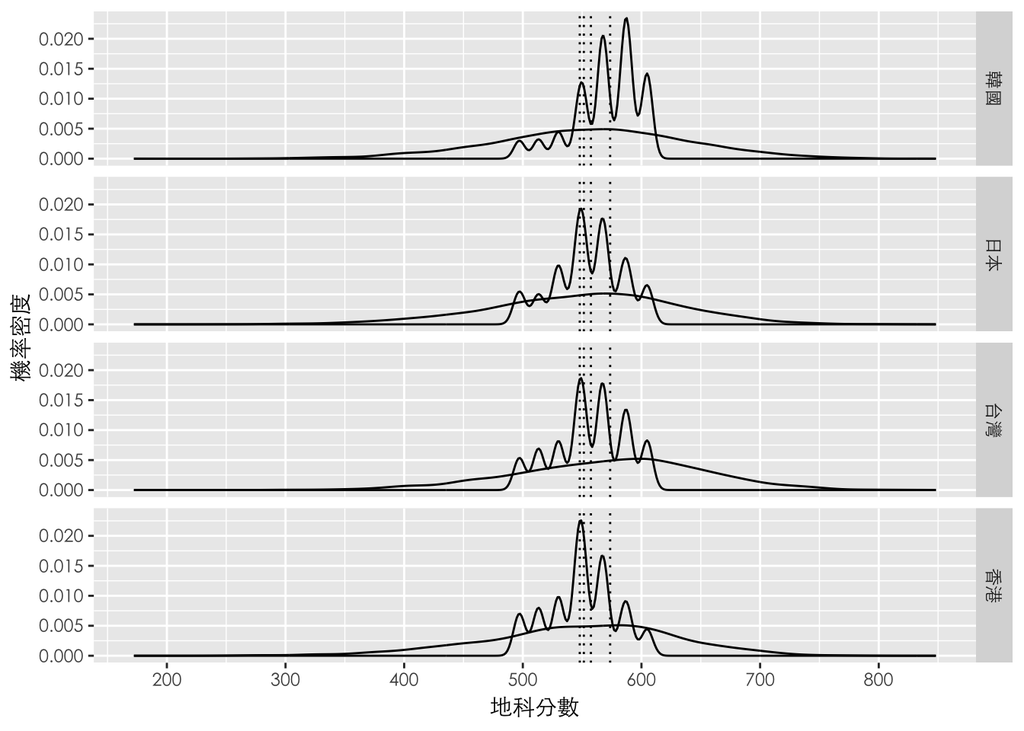

```r
ggplot(data = fit_m2, aes(x = 地科, group = 國家)) +
  stat_density(geom = 'path', position = 'identity') +
  stat_density(geom = 'path', position = 'identity', aes(x = fitted)) +
  geom_vline(xintercept = c(with(data, tapply(地科,國家, mean))), linetype = 'dotted')+
  facet_grid(國家 ~ .) +
  scale_x_continuous(breaks = seq(200, 900, by = 100))+
  labs(x = '地科分數', y = '機率密度') +
  theme(text=element_text(family="Heiti TC Light"))
```

### Part C. 分析資料集當中的其他變項是否和地科成績有關

##### 看看家裡有無網路跟地科間的關係

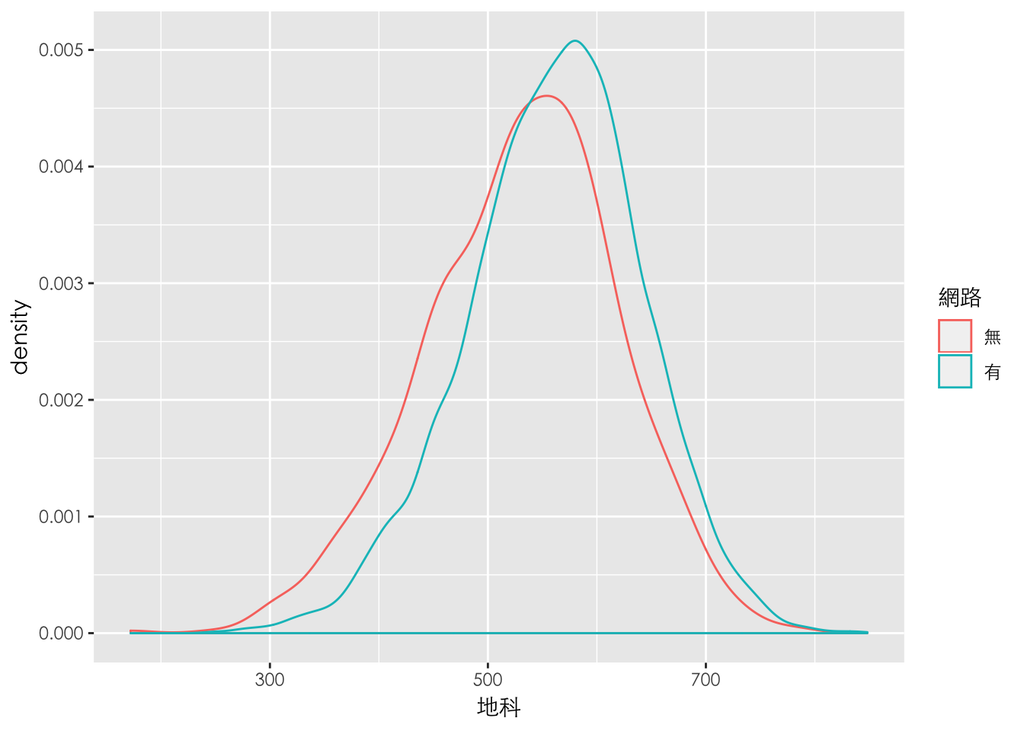

```r
ggplot(data, aes(地科, colour = 網路)) + geom_density() +
   theme(text=element_text(family="Heiti TC Light"))
```

##### 看看不同國家、有無網路的學生地科平均與對應的平均數標準誤

```r
summary(m4 <- lm(地科 ~ 國家 + 網路, data = data[, c('網路', '地科', '國家') ]))
```

```
##
## Call:
## lm(formula = 地科 ~ 國家 + 網路, data = data[, c("網路",
##     "地科", "國家")])
##
## Residuals:
##     Min      1Q  Median      3Q     Max
## -354.60  -51.37    4.27   54.49  280.17
##
## Coefficients:
##             Estimate Std. Error t value Pr(>|t|)
## (Intercept)  526.813      2.972 177.255  < 2e-16 ***
## 國家日本      -2.825      1.872  -1.509    0.131
## 國家台灣      17.554      1.724  10.185  < 2e-16 ***
## 國家香港      -9.491      1.879  -5.052 4.42e-07 ***
## 網路有        31.390      2.779  11.295  < 2e-16 ***
## ---
## Signif. codes:  0 '***' 0.001 '**' 0.01 '*' 0.05 '.' 0.1 ' ' 1
##
## Residual standard error: 81 on 15544 degrees of freedom
## Multiple R-squared:  0.02305,    Adjusted R-squared:  0.0228
## F-statistic: 91.69 on 4 and 15544 DF,  p-value: < 2.2e-16
```

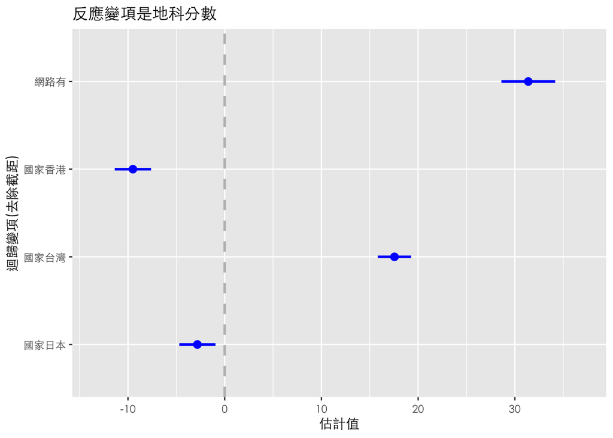

```r
coefplot(m4, predictors = c('網路', '地科', '國家'),
         xlab = '估計值', ylab = '迴歸變項(去除截距)', title = '反應變項是地科分數') +
  theme(text=element_text(family="Heiti TC Light"))
```